# JSON

Ayman Ighwair

10/14/2019

# Introduction

## What is JSON ?

JSON is short for JavaScript Object Notation, and is a popular format for storing and exchanging data on the web. It’s known for its simplicity for humans to read and write and for machines to parse and generate

## What makes up the JSON language?

Every JSON contains a key and a value. . Together they make a key/value pair.  
* Key: A key is always a string enclosed in quotation marks. * Value: A value can be a string, number, boolean expression, array, or object.

## Importance of JSON

JSON is ideal for storing temporary data JSON must be stored in text fomat. An advantage of this is that it can be used as a data format for any programming language, providing a high level of interoperability. This also means data stored in JSON files are easily sent between servers.

##Reading in JSON files

I used the jsonlite package as it takes care of different json delimeters and simplifies the process of reading in the data

# About the Data

## Intro

Gathered from the New York Times API for Hardcover Fiction best sellers from June 7, 2008 to July 22, 2018. This dataset provides a summary of several best-selling fiction books.

## Variables

- Author
- title
- publisher
- rank
- price

Below is the average price of NYT best selling fiction books :

```r
mn <- as.numeric(yelp_tbl$`price.$numberDouble`)

Average <- function(vector) {
  mean <- mean(vector, na.rm=TRUE)
  stdev <- sd(vector, na.rm=TRUE)
  return(list( mean = mean, sd = stdev))
}

Average(mn)
```

```
## $mean
## [1] 26.81837
##
## $sd
## [1] 1.78772
```

Also, a newly created column calculting the difference in ranks that happened in a week:

```r
book<-yelp_tbl %>% select(author,title,publisher,`price.$numberDouble`,`rank.$numberInt`,`rank_last_week.$numberInt`) %>% arrange(`rank.$numberInt`)

gy<-book %>% mutate(week_rank_diff = as.numeric(`rank_last_week.$numberInt`)- as.numeric(`rank.$numberInt`)) %>% select(author,title,week_rank_diff)
gy
```

```
## # A tibble: 10,195 x 3
##    author                             title              week_rank_diff
##    <chr>                              <chr>                       <dbl>
##  1 Dean R Koontz                      ODD HOURS                      -1
##  2 Laurell K Hamilton                 BLOOD NOIR                     -1
##  3 Lee Child                          NOTHING TO LOSE                -1
##  4 James Patterson and Howard Roughan SAIL                           -1
##  5 Janet Evanovich                    FEARLESS FOURTEEN              -1
##  6 Janet Evanovich                    FEARLESS FOURTEEN               0
##  7 Brad Thor                          THE LAST PATRIOT               -1
##  8 Nora Roberts                       TRIBUTE                        -1
##  9 Nora Roberts                       TRIBUTE                         0
## 10 Daniel Silva                       THE SECRET SERVANT             -1
## # ... with 10,185 more rows
```

The Top 10 publishers :

```r
top_10 <-book %>% count(publisher) %>%  arrange(desc(n)) %>% top_n(10)
kable(top_10)
```

| publisher | n |
| --- | --- |
| Putnam | 1061 |
| Little, Brown | 943 |
| Grand Central | 619 |
| Knopf | 559 |
| Doubleday | 475 |
| Scribner | 456 |
| Ballantine | 421 |
| Delacorte | 347 |
| Bantam | 319 |
| Simon & Schuster | 308 |

Below is a scatter plot to find if theres any correlation between Price and book rank :

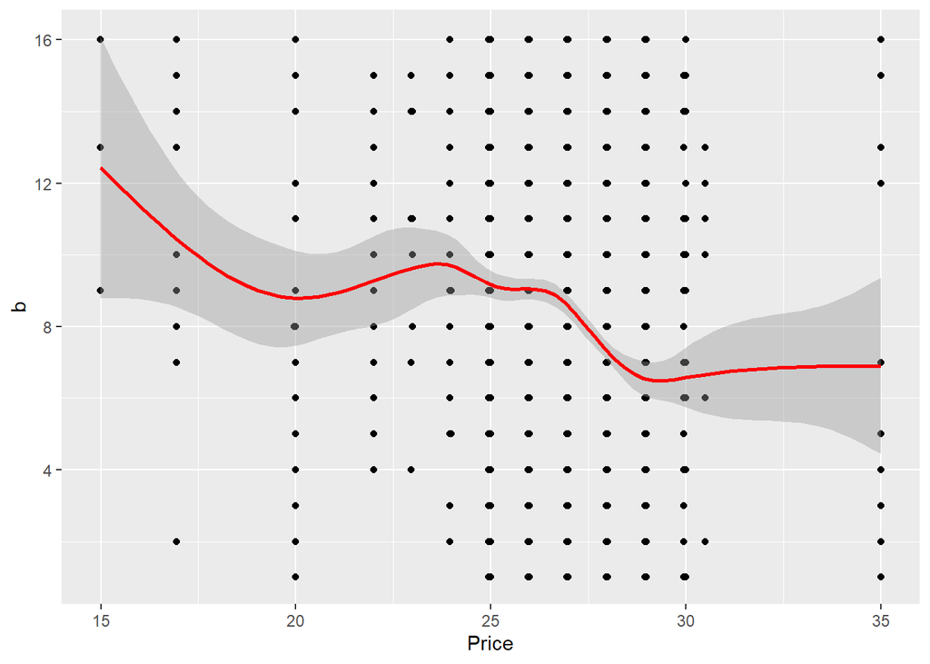

```r
price <- as.numeric(yelp_tbl$`price.$numberDouble`)
a<-as.numeric(yelp_tbl$`rank_last_week.$numberInt`)
b<- as.numeric(yelp_tbl$`rank.$numberInt`)
sctr<- data.frame(price,b)
sctr<-na.omit(sctr)
g<-ggplot(sctr,aes(x= price ,y=b))
g + geom_point() + geom_smooth(colour="red") +xlab("Price")
```

Count of the different ranks

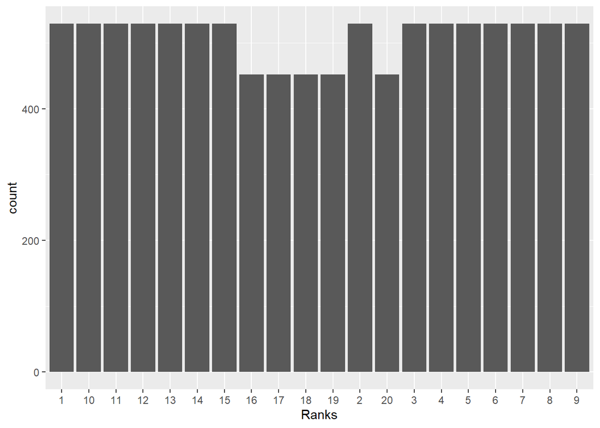

```r
book<-yelp_tbl %>% select(author,title,publisher,`price.$numberDouble`,`rank.$numberInt`,`rank_last_week.$numberInt`) %>% arrange(`rank.$numberInt`)

g<-ggplot(book,aes(x= `rank.$numberInt`))
g + geom_bar() + xlab("Ranks")
```